# Lab 8: Functions and Conditionals

Stat 133, Spring 2022

### Learning Objectives

> - Learn how to write simple functions
> - Get into the habit of writing simple functions
> - Get into the habit of documenting functions
> - Use conditionals if-then-else

### General Instructions

- Write your descriptions, explanations, and code in an `Rmd` (R markdown) file.
- Name this file as `lab08-first-last.Rmd`, where `first` and `last` are your first and last names (e.g. `lab08-gaston-sanchez.Rmd`).
- Knit your `Rmd` file as an html document (default option).
- Submit your `Rmd` and `html` files to bCourses, in the corresponding lab assignment.

## 1) Introduction

In this lab you will practice writing simple functions, and some basic examples to make sure that the functions work as expected. Later in the course we will see how to write assertions (i.e. tests) for your functions in a more formal way.

In addition to writing the functions, you should also practice documenting your functions. Writing this type of documentation should become second nature. To do this, include roxygen comments such as:

- `#' @title Name of your function`
- `#' @description What the function does`
- `#' @param x input(s) of your function`
- `#' @return output of your function`

## 2) Polynomials

In this problem we want to see whether the graph of a given polynomial will cross or touch the *x* axis in a given interval.

Let’s begin with the polynomial:

$$f(x) = x^2 - 1$$

The first thing to do is to write a function for the polynomial, for instance:

```r
#' @title polynomial function x^2-1
#' @description returns the value of the polynomial at a specified x value
#' @param x value of x (numeric)
#' @return computed output

poly1 <- function(x) {
  x^2 - 1
}
```

Once you have a function for the polynomial, you can create a set of pairs of points $x$ and $y = f(x)$, and then use them to graph the polynomial

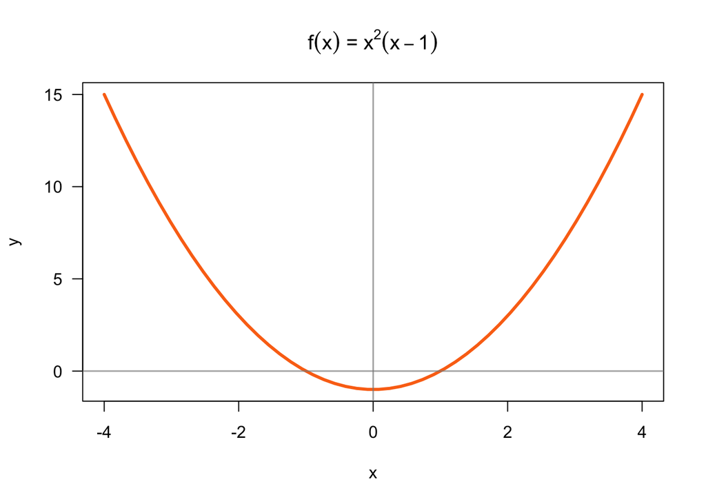

```r
# set of points
x <- seq(-4, 4, length.out = 50)
y <- poly1(x)

# graph polynomial
plot(x, y, type = 'l', lwd = 3, col = "#FB7215", las = 1)
abline(h = 0, v = 0, col = '#888888aa', lwd = 1.5)
title(main = expression(paste(f(x), ' = ', x^2, (x - 1))))
```

### 2.1) Your Turn: Polynomial functions

Write functions and graph the following polynomials in the x-axis interval -4 to 4:

1. $f(x) = x^3$

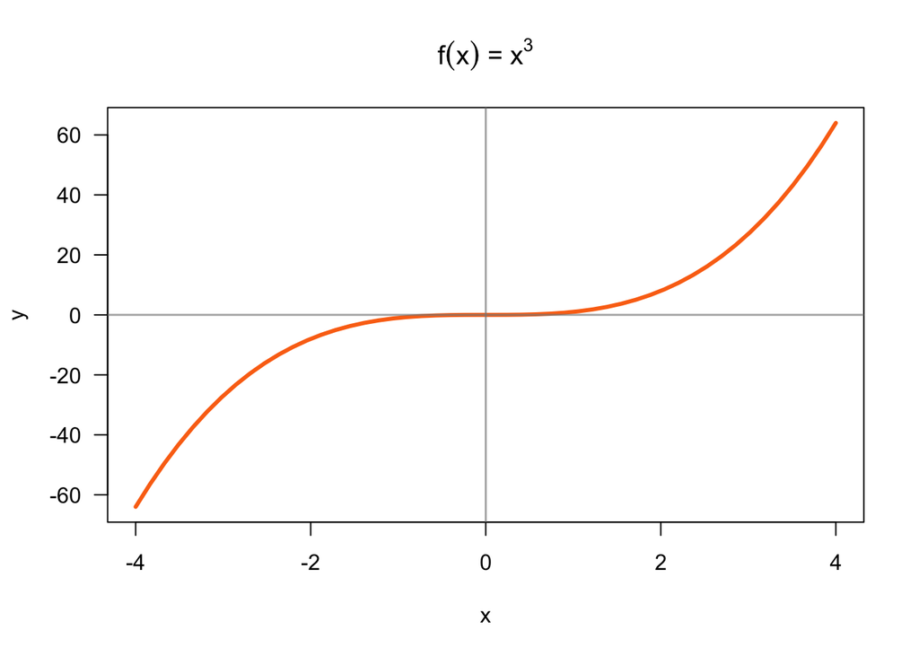

```r
#' @title polynomial function x^3
#' @description returns the value of the polynomial at a specified x value
#' @param x value of x (numeric)
#' @return computed output

cubic <- function(x) {
  x^3
}

# set of points
x <- seq(-4, 4, length.out = 50)
y <- cubic(x)

# graph polynomial
plot(x, y, type = 'l', lwd = 3, col = "#FB7215", las = 1)
abline(h = 0, v = 0, col = '#888888aa', lwd = 1.5)
title(main = expression(paste(f(x), ' = ', x^3)))
```

2. $f(x) = (x^2 - 1)(x + 3)^3$

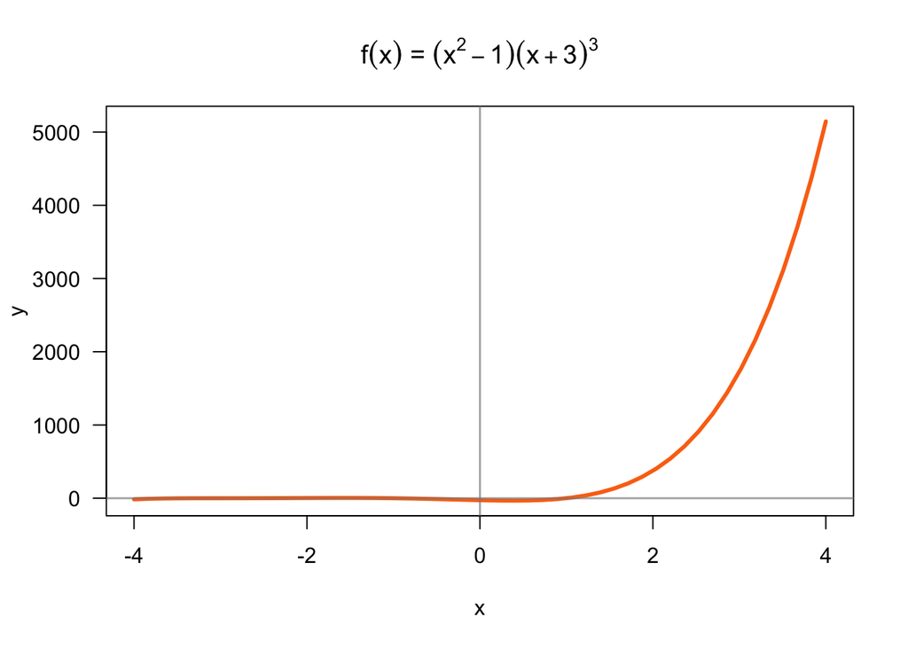

```r
#' @title polynomial function (x^2-1)(x+3)^3
#' @description returns the value of the polynomial at a specified x value
#' @param x value of x (numeric)
#' @return computed output

polyb <- function(x) {
  (x^2-1) * (x+3)^3
}

# set of points
x <- seq(-4, 4, length.out = 50)
y <- polyb(x)

# graph polynomial
plot(x, y, type = 'l', lwd = 3, col = "#FB7215", las = 1)
abline(h = 0, v = 0, col = '#888888aa', lwd = 1.5)
title(main = expression(paste(f(x), ' = ', (x^2-1), (x+3)^3)))
```

3. $f(x) = (x^2 - 1)(x^2 - 9)$

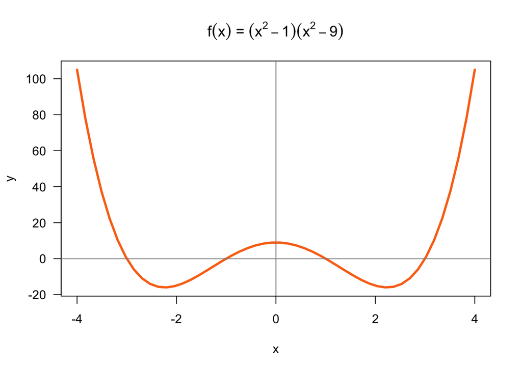

```r
#' @title polynomial function (x^2-1)(x^2-9)
#' @description returns the value of the polynomial at a specified x value
#' @param x value of x (numeric)
#' @return computed output

polyc <- function(x) {
  (x^2-1) * (x^2-9)
}

# set of points
x <- seq(-4, 4, length.out = 50)
y <- polyc(x)

# graph polynomial
plot(x, y, type = 'l', lwd = 3, col = "#FB7215", las = 1)
abline(h = 0, v = 0, col = '#888888aa', lwd = 1.5)
title(main = expression(paste(f(x), ' = ', (x^2-1), (x^2-9))))
```

## 3) Area of a circle

Consider a circle with `radius = 2`. The area of this circle can be computed in R as:

```r
# area of circle with radius 2
r <- 2
area <- pi * r^2
area
```

```
## [1] 12.56637
```

### 3.1) Your Turn: `circle_area()` version 1

Write a function `circle_area()` that calculates the area of a circle. This function must take one argument `radius`. Give `radius` a default value of 1. Don’t forget to include roxygen comments to document your function!

```r
#' @title area of a circle
#' @description returns the value of a circle with radius x having a default radius of 1
#' @param x radius of the circle (numeric)
#' @return computed area

circle_area <- function(radius = 1) {
  pi * radius^2
}
```

Test your function with:

- `circle_area()`
- `circle_area(radius = 3)`

```r
circle_area()
```

```
## [1] 3.141593
```

```r
circle_area(radius = 3)
```

```
## [1] 28.27433
```

### 3.2) Your Turn: `circle_area()` version 2

Modify your `circle_area()` function in order to include a `stop()` statement. If `radius` is negative, then the function should stop with a message like: `"radius cannot be negative"`.

```r
#' @title area of a circle
#' @description returns the value of a circle with radius x with a default radius of 1
#' @param x radius of the circle (numeric)
#' @return computed area

circle_area <- function(radius = 1) {
  if (radius < 0) {
    stop("radius cannot be negative")
  }
  pi * radius^2
}
```

Test your modified `circle_area()` with `radius = -2`; the function should return a stop message:

```r
circle_area(radius = -2)
```

```
## Error in circle_area(radius = -2): radius cannot be negative
```

## 4) Area of a Cylinder

For a given cylinder of radius $r$ and height $h$ the surface area $A$ is given by:

$$\text{area} = 2 \pi r h + 2 \pi r^2$$

For example. Say you have a cylinder with radius = 2, and height = 3.

```r
# cylinder variables
r = 2  # radius
h = 3  # height

# area of cylinder
(2 * pi * r * h) + (2 * pi * r^2)
```

```
## [1] 62.83185
```

Notice that the formula of the area of a cylinder includes the area of a circle: $\pi r^2$.

### 4.1) Your Turn: `cylinder_area()` function

Write a function `cylinder_area()`, that calls `circle_area()`, to compute the area of a cylinder.

```r
#' @title area of a cylinder
#' @description returns the area of a cylinder with varying radius and height
#' @param radius radius of the cylinder (numeric)
#' @param height height of the cylinder (numeric)
#' @return computed area

cylinder_area <- function(radius = 1, height = 1) {
  if (radius < 0) {
    stop("radius cannot be negative")
  }
  if (height < 0) {
    stop("height cannot be negative")
  }
  (2 * pi * radius * height) + (2 * pi * radius^2)
}
```

This function must take two arguments: `radius` and `height`. Give both arguments a default value of 1. In addition, the function should stop if any of `radius` or `height` are negative.

Test your function with:

- `cylinder_area()`
- `cylinder_area(radius = 2, height = 3)`
- `cylinder_area(radius = -2, height = 1)`
- `cylinder_area(radius = 2, height = -1)`
- `cylinder_area(radius = -2, height = -1)`

```r
cylinder_area()
```

```
## [1] 12.56637
```

```r
cylinder_area(radius = 2, height = 3)
```

```
## [1] 62.83185
```

```r
cylinder_area(radius = -2, height = 1)
```

```
## Error in cylinder_area(radius = -2, height = 1): radius cannot be negative
```

```r
cylinder_area(radius = 2, height = -1)
```

```
## Error in cylinder_area(radius = 2, height = -1): height cannot be negative
```

```r
cylinder_area(radius = -2, height = -1)
```

```
## Error in cylinder_area(radius = -2, height = -1): radius cannot be negative
```

## 5) Even and Odd Numbers

Any number that can be exactly divided by 2 is called as an **even** number. R provides the modulo operator, `"%%"` that can be used to determine if a number is even or odd.

To be more precise, the modulo operator returns the remainder or signed remainder of a division.

For example, `4 %% 2` evaluates to 0, because 4 divided by 2 has a quotient of 2 and a remainder of 0:

```r
# 4 is exactly divisible by 2
4 %% 2
```

```
## [1] 0
```

In contrast, `5 %% 2` would evaluate to 1, because 5 divided by 2 has a quotient of 2 and a remainder of 1

```r
# 5 is not exactly divisible by 2
5 %% 2
```

```
## [1] 1
```

### 5.1) Your Turn: Even number

Write a function `is_even()` that determines whether a number is even (i.e. multiple of 2). If the input number is even, the output should be `TRUE`. If the input number is odd, the output should be `FALSE`. If the input is not a number, the output should be `NA`

```r
#' @title even number
#' @description returns TRUE if the input is even, FALSE if it is odd, or NA if the input is not numeric
#' @param x input to be tested (numeric)
#' @return boolean corresponding to the description

is_even <- function(x) {
  if (is.numeric(x) == FALSE) {
    return('NA')
  }
  if (x %% 2 == 0) {
    return(TRUE)
  }
  if (x %% 2 == 1) {
    return(FALSE)
  }
}
```

Test your function with:

- `is_even(10)`
- `is_even(33)`
- `is_even('a')`

```r
is_even(10)
```

```
## [1] TRUE
```

```r
is_even(33)
```

```
## [1] FALSE
```

```r
is_even('a')
```

```
## [1] "NA"
```

### 5.2) Your Turn: Odd number

Use your function `is_even()` to write a function `is_odd()` that determines if a number is odd (i.e. not a multiple of 2). If a number is odd, the output should be `TRUE`; if a number is even the output should be `FALSE`; if the input is not a number the output should be `NA`

```r
#' @title odd number
#' @description returns TRUE if the input is odd, FALSE if it is even, or NA if the input is not numeric
#' @param x input to be tested (numeric)
#' @return boolean or NA corresponding to the description

is_odd <- function(x) {
  if (is.numeric(x) == FALSE) {
    return('NA')
  }
  if (x %% 2 == 0) {
    return(FALSE)
  }
  if (x %% 2 == 1) {
    return(TRUE)
  }
}
```

Test `is_odd()` with the following cases:

- `is_odd(1)`
- `is_odd(4)`
- `is_odd('a')`

```r
is_odd(1)
```

```
## [1] TRUE
```

```r
is_odd(4)
```

```
## [1] FALSE
```

```r
is_odd('a')
```

```
## [1] "NA"
```

## 6) If Conditionals

Say you have a number $x$, and you want to compute another number $y$ that takes a value depending on $x$ as follows:

$$y = \begin{cases}
0 & \text{if} & x < 0 \\
& \\
x & \text{if} & x \in [0, 100] \\
& \\
100 & \text{if} & x > 100
\end{cases}$$

### 6.1) Your Turn: `squish()` function

Write a function `squish()` that “squishes” a number into the interval $[0, 100]$, so that a number less than 0 is replaced by 0 and a number greater than 100 is replaced by 100.

```r
#' @title squish
#' @description returns the value of a number if in the range 0 to 100. If not, it returns 0 or 100 depending on which value is closest
#' @param x input that will be squished (numeric)
#' @return value within the range 0 to 100

squish <- function(x) {
  if (x < 0) {
    return(0)
  }
  if (x > 100) {
    return(100)
  }
  else {
    return(x)
  }
}
```

Test `squish()` with:

- `squish(-5)`
- `squish(180)`
- `squish(50)`
- `squish(0)`
- `squish(100)`

```r
squish(-5)
```

```
## [1] 0
```

```r
squish(180)
```

```
## [1] 100
```

```r
squish(50)
```

```
## [1] 50
```

```r
squish(0)
```

```
## [1] 0
```

```r
squish(100)
```

```
## [1] 100
```